# ECS230 Hw4

Eric Kalosa-Kenyon

28 November 2017

Abstract

In this assignment, I fit polynomials to data using LAPACK/BLAS matrix functions.

# Fitting a polynomial

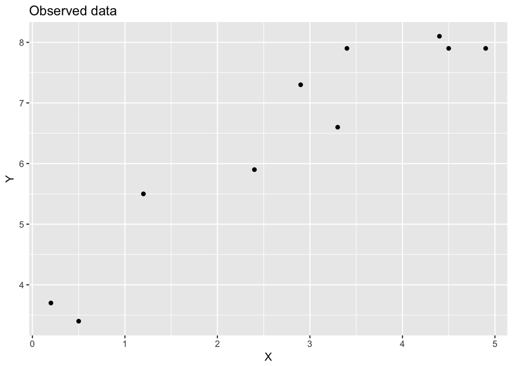

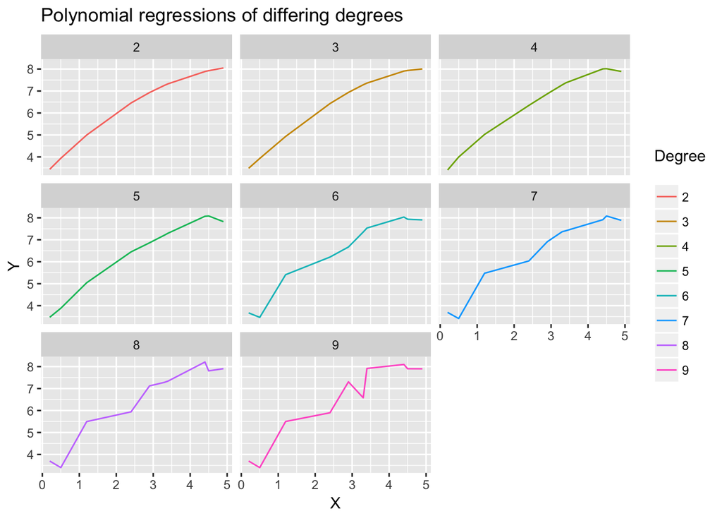

# Coefficients of polynomials of degree 5 and 9

The coefficients of the 5th degree polynomial regression are

## degree.5.coefficients

3.302285  
0.548539  
1.698495  
-1.062627  
0.254667  
-0.021502

and

## degree.9.coefficients

260.529583  
-2445.719137  
7770.566339  
-11510.585254  
9330.883395  
-4481.798700  
1311.960882  
-230.002574  
22.203295  
-0.907912

Note that we can’t fit a polynomial of degree 10 (a polynomial with constant term, $x^1$, …, and an $x^{10}$ term) or higher - the associated design matrix $X$ would be rank-defficient, so the sample covariance matrix $X^\top X$ would be non-invertible and the coefficients $\hat{\beta}_{p\ge 11} = X(X^\top X)^{-1}X^\top Y$ non-computable.

# Quality of fit

Successively higher degree polynomials had lower L2 error; but the model with lowest AIC and the best cross-validated LASSO model, determined by the following and subsequent snippets, are more appropriate models than the 9th degree polynomial.

## AIC

```r
dd = d[d$D == 0, c("X", "Y")]
a = data.frame(degree=numeric(), aic=numeric())
for(i in 1:8){
    m = lm(Y ~ poly(X, i), data=dd)
    # print(paste("AIC for poly of degree", d, ":", AIC(m)))
    a[i,] = c(i-1, AIC(m))
}
```

| degree | aic |
| --- | --- |
| 0 | 22.08218 |
| 1 | 19.67163 |
| 2 | 21.60936 |
| 3 | 23.28583 |
| 4 | 24.99388 |
| 5 | 23.28136 |
| 6 | 23.96639 |
| 7 | 23.52776 |

## LASSO

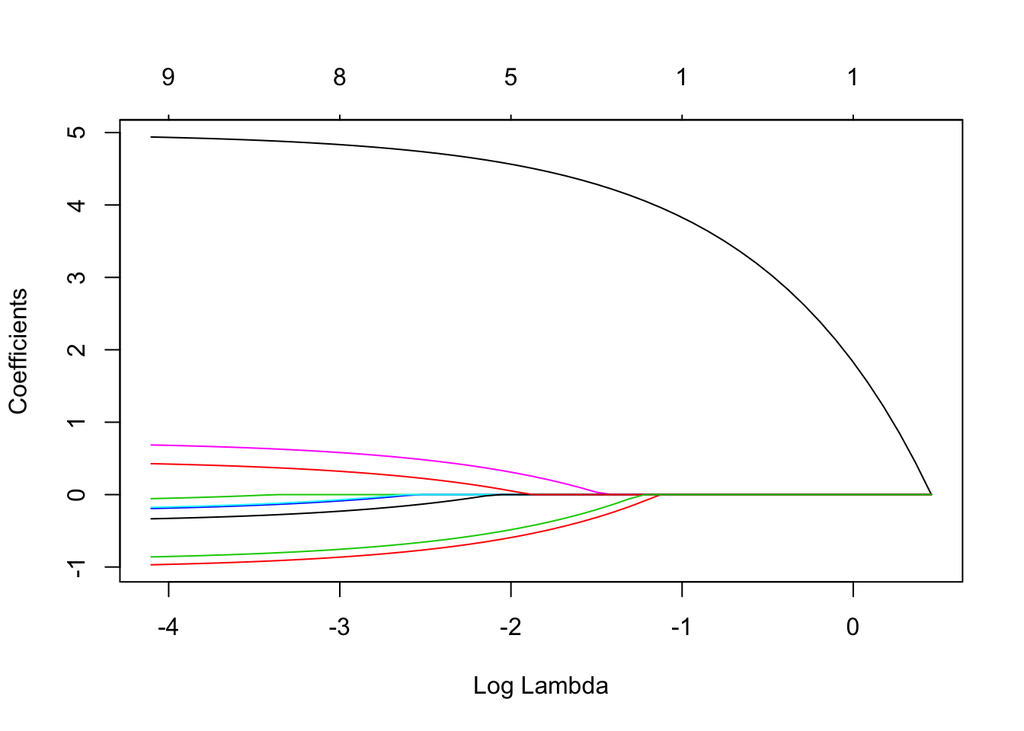

```r
x = matrix(model.matrix(~ poly(X, 9), dd), 10, 10)[,2:10]
y = dd$Y
mlas = glmnet(x, y, alpha=1) # alpha=1 for LASSO
plot(mlas, xvar="lambda")
```

```r
# crossval to select best lambda
cv.mlas = cv.glmnet(x, y, alpha=1) # alpha=1 for LASSO
```

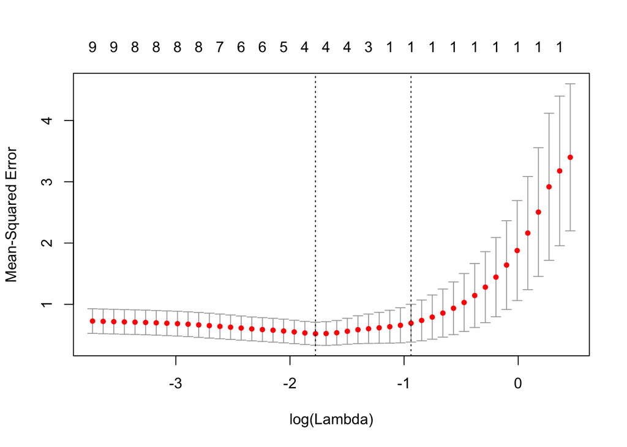

```r
plot(cv.mlas)
```

```r
best.lambda <- cv.mlas$lambda.min

mlas.opt = glmnet(x, y, alpha=best.lambda)
```

# Appendix

The following sections contain useful supplementary information.

## C program graphs

The following graphs are those generated by the C program using gnuplot.

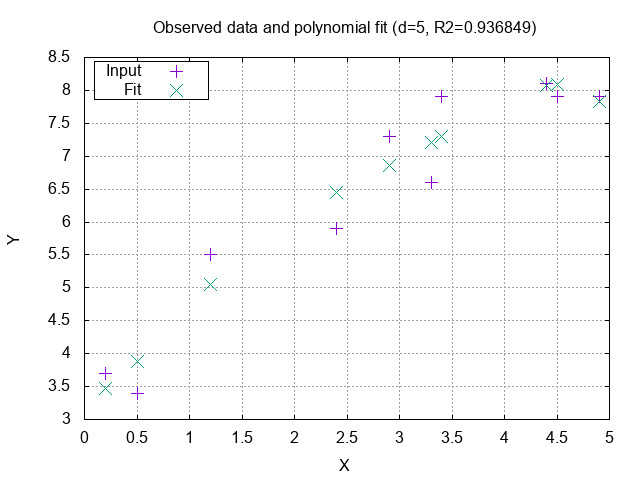

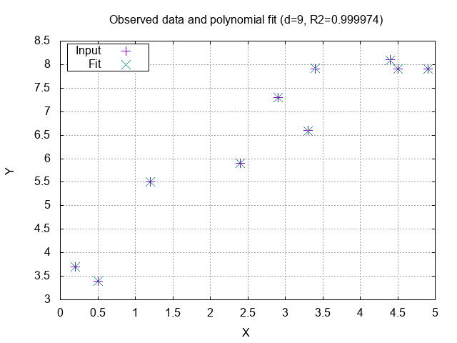

## Data

The table below shows the $(x,y)$ pairs for each degree of polynomial tested. The column “D” shows the degree of the polynomial used to fit the printed “Y” value at the associated “X” value. Rows with “D=0” holds the input data.

| X | Y | D |
| --- | --- | --- |
| 0.5 | 3.936952 | 2 |
| 0.2 | 3.436143 | 2 |
| 1.2 | 4.996091 | 2 |
| 2.9 | 6.930559 | 2 |
| 3.4 | 7.327584 | 2 |
| 2.4 | 6.455381 | 2 |
| 4.4 | 7.887176 | 2 |
| 4.5 | 7.925941 | 2 |
| 4.9 | 8.049742 | 2 |
| 3.3 | 7.254431 | 2 |
| 0.5 | 3.929760 | 3 |
| 0.2 | 3.482039 | 3 |
| 1.2 | 4.931339 | 3 |
| 2.9 | 6.937048 | 3 |
| 3.4 | 7.361112 | 3 |
| 2.4 | 6.428041 | 3 |
| 4.4 | 7.906626 | 3 |
| 4.5 | 7.936183 | 3 |
| 4.9 | 8.004185 | 3 |
| 3.3 | 7.283668 | 3 |
| 0.5 | 3.994173 | 4 |
| 0.2 | 3.401635 | 4 |
| 1.2 | 5.022712 | 4 |
| 2.9 | 6.872525 | 4 |
| 3.4 | 7.373770 | 4 |
| 2.4 | 6.345580 | 4 |
| 4.4 | 8.006532 | 4 |
| 4.5 | 8.015461 | 4 |
| 4.9 | 7.889603 | 4 |
| 3.3 | 7.278010 | 4 |

[output cut: 60 more lines]

## Source code

The following is the source used for the creation of this report. The code handed in on the CSIF computers is slightly different from the following source. The hand-in code conforms to the specifications of the assignment, wheras the following source is formatted to work with the project’s directory structure. No major algorithmic changes were made.

```
// Author: Eric Kalosa-Kenyon
//
// This program performs least squares polynomial fitting using BLAS and LAPACK
//
// Takes:
//      d - command line input, degree of polynomial to fit
//      data.dat - x and y values to fit polynomial to
// Returns:
//      StdIO - fit and intermediate results
//
// Sources:
// 1. https://www.cs.bu.edu/teaching/c/file-io/intro/
// 2. http://www.netlib.org/clapack/cblas/dgemm.c
// 3. https://www.math.utah.edu/software/lapack/lapack-blas/dgemm.html
// 4  http://www.math.utah.edu/software/lapack/lapack-d/dpotrf.html
// 5. https://stackoverflow.com/questions/3521209/making-c-code-plot-a-graph-automatically
// 6. https://linux.die.net/man/3/getline

#include "stdio.h"
#include "stdlib.h"
#include "string.h"
#include "math.h"
#include "Accelerate/Accelerate.h"
// #include "cblas.h"

// BEGIN PROTOTYPES
void dgemm_(char * transa, char * transb, int * m, int * n, int * k,
    double * alpha, double * A, int * lda,
    double * B, int * ldb, double * beta,
    double *, int * ldc);

void dgemv_(char * trans, int * m, int * n,
    double * alpha, double * A, int * lda,
    double * x, int * incx, double * beta,
    double * y, int * incy);

int dpotrf_(char * uplo, int * n,
    double * A, int * lda, int * info);

void dtrsm_(char * side, char * uplo, char * transa, char * diag,
    int * m, int * n, double * alpha, double * A,
    int * lda, double * B, int * ldb);
// END PROTOTYPES

// BEGIN VARIABLES
// for general configuration
const char data_fn[] = "../data/data.dat"; // location of the input data
int d; // counter for the degree of the polynomial to fit
int i, j; // loop counters
float x, y; // for reading x and y from data_fn
int n; // size of the input data (n by 2 i.e. n xs and n ys)
char string[1024]; // target string for snprintf()
int firstline; // determines whether reading first line of data.dat or not
float numstab = 100.0; // scale up input data for numerical stability

// file handling objects
FILE *ifp; // pointer to the file object containing the input data
FILE * out_raw;
FILE * out_fit;
FILE * out_coef;
FILE * out_designMx;
FILE * gnuplotPipe;
char *mode = "r"; // opening mode for the file above

// CBLAS/LAPACK inputs
char TRANSA;
char TRANSB;
char TRANS;
double ALPHA;
double BETA;
int M;
int N;
int K;
int LDA;
int LDB;
int LDC;
int INCB;
int INCY;
int INCP;
char SIDE;
char DIAG;

// stats calculations
double mu;
double sse;
double var;
double r;
// END VARIABLES

// BEGIN MAIN
int main(int argc, char** argv)
{
    d = atoi(argv[1]) + 1; // degree of fit polynomial from commandline

    // read data into memory from disk
    ifp = fopen(data_fn, mode);
    if (ifp == NULL) {
        fprintf(stderr, "Cannot open file\n"); // error if it can't open
        exit(1);
    }

    n = 1;
    firstline = 1;
    double *X = (double*) malloc(n*d* sizeof(double)); // placeholder malloc
    double *Y = (double*) malloc(n* sizeof(double));

    /* while (fscanf(ifp, "%f %f", &x, &y) != EOF) { // for each line in the file */
    char * line = NULL;
    size_t len = 0;
    ssize_t read;
    char * pch;
    while ((read = getline(&line, &len, ifp)) != -1){
        if(firstline == 1){

            printf("Read first line (len %zu) : ", read);
            printf("%s\n", line);
            n = atoi(line); // n_obs is first line of data.dat
            firstline = 0;
            printf("Using %d observations\n", n);

            // allocate memory for the input data
            // NOTE: X is col-major indexed i.e. X[i + n*j] = X_(i,j)
            X = realloc(X, n*d*sizeof(double));
            Y = realloc(Y, n*sizeof(double));
            if ((X == NULL) || (Y == NULL)) {
                fprintf(stderr, "malloc failed\n");
                return(1);
            }else{
                printf("Memory allocated for input and design matrices\n\n");
            }

        }else{

            printf("Read line (len %zu) : ", read);
            printf("%s", line);
            pch = strtok(line," "); // parse line into x, y floats
            x = INFINITY;
            y = INFINITY;
            while (pch != NULL) {
                if(x == INFINITY){
                    x = atof(pch);
                }else{
                    y = atof(pch);
                }
                /* printf("%f\n", atof(pch)); */
                pch = strtok(NULL, " ");
            }

            // subsequent lines are the observations
            for(j = 0; j < d+1; j++){
                // each col of X is ((x_i)^j)_{i=1..n}, j<=d
                X[i + j*n] = pow(x, j)*numstab;
            }
            Y[i] = y*numstab;

            i++;

        }
    }
    fclose(ifp);
    printf("\n");

    // print the X and Y matrices
    printf("Y\t\t"); // BEGIN formatting printing header
    for(j = 0; j < d; j++){
        printf("X^%d\t\t", j);
    }
    printf("\n"); // END formatting printing header

    for(i = 0; i < n; i++){ // BEGIN print X and Y
        printf("%f\t", Y[i]);
        for(j = 0; j < d; j++){
            printf("%f\t", X[i + j*n]);
        }
        printf("\n");
    } // END print X and Y

    // compute A=X^T X using BLAS::dgemm()
    // initialize
    TRANSA = 'T'; // transpose the matrix X for (X^T X)
    TRANSB = 'N';
    ALPHA = 1.0; // dgemm(A,B,C) : C <- alpha*AB + beta*C
    BETA = 0.0;
    M = d; // rows of X^T
    N = d; // columns of X
    K = n; // columns of X^T and rows of X
    LDA = n; // leading dimension of X
    LDB = n; // leading dimension of X
    LDC = d; // leading dimension of A

    // allocate memory for A
    double *A = (double*) malloc(d*d* sizeof(double));
    if (A == NULL) {
        fprintf(stderr, "malloc failed\n");
        return(1);
    }

    // compute A = X^T X
    dgemm_(&TRANSA, &TRANSB,
        &M, &N, &K,
        &ALPHA, X, &LDA, X, &LDB, &BETA,
        A, &LDC);

    // print A
    printf("\nA = X^T X\n");
    for(i = 0; i < d; i++){
        for(j = 0; j < d; j++){
            printf("%f\t", A[i + j*d]);
        }
        printf("\n");
    }
```

```
    // Compute P = Xt y using BLAS::dgemm()
    // initialize
    TRANS = 'T'; // transpose the matrix X for (X^T y)
    M = n; // rows of X (number of obs)
    N = d; // columns of X (degree of polynom)
    LDA = n; // leading dimension of X
    INCY = 1; // increment for the input vector
    INCP = 1; // increment for the input vector

    // allocate memory for P = X^T y
    double *P = (double*) malloc(d* sizeof(double));
    if (P == NULL) {
        fprintf(stderr, "malloc failed\n");
        return(1);
    }

    // compute P = X^T y using dgemv
    dgemv_(&TRANS, &M, &N,
        &ALPHA, X, &LDA, Y, &INCY, &BETA,
        P, &INCP);

    // print P
    printf("\nP = X^T y\n");
    for(i = 0; i < d; i++){
        printf("%f\t", P[i]);
    printf("\n");
    }

    // Compute Choelsky decomposition XTX = A = LTL i.e. get L
    // allocate memory for L
    double *L = (double*) malloc(d*d* sizeof(double));
    if (L == NULL) {
        fprintf(stderr, "malloc failed\n");
        return(1);
    }

    // set up L = A for subsequent diagonalization
    for(i=0; i<d*d; i++){
        L[i] = A[i];
    }

    // set up the diagonalization and run it
    char UPLO = 'L'; // lower triangular
    int ORD = d; // L is order d
    int LDD = d; // leading dimension of matrix
    int INFO = 0; // output for diagonalization
    dpotrf_(&UPLO, &ORD, L, &LDD, &INFO);

    if(INFO != 0){
        fprintf(stderr, "Choelsky decomosition failed\n");
        return(1);
    }

    // set the above-diagonal entries to 0 - this is just an aesthetic thing
    for(i=0; i<d; i++){
        for(j=0; j<d; j++){
            if(j>i){
                L[i + d*j] = 0.0;
            }
        }
    }

    // print resultant diagonalized matrix L
    printf("\nL = Chol(A)\n");
    for(i = 0; i < d; i++){
        for(j = 0; j < d; j++){
            printf("%f\t", L[i + j*d]);
        }
        printf("\n");
    }

    // Solve for b (Xb=y) using BLAS::dtrsm()
    //  first, some algebra:
    //  Xb = y -> XtX b = Xt y -> Ab = p -> LLt b = p
    //  let Ltb = q, then solve L q = p using dtrsm_() for q
    //  upon solving for q, solve Ltb = q for b using dtrsm_()

    // set up the first triangular solve for L Q = P and run it
    SIDE = 'L'; // left, i.e. L q = p rather than q L = p
    UPLO = 'L'; // L is lower triangular
    TRANSA = 'N'; // solving L q = b not Lt
    DIAG = 'N'; // L is not unit diagonal (using Choelsky not LDL decomp)
    M = d; // rows of resultant vector P
    N = 1; // columns of resultant vector P
    ALPHA = 1.0; // coef for the rhs vector P
    LDA = d; // leading dimension on the lhs multiplier L
    LDB = d; // leading dimension of the rhs vector P

    // allocate a copy of P for the solution Q
    double *Q = (double*) malloc(d* sizeof(double));
    if (Q == NULL) {
        fprintf(stderr, "malloc failed\n");
        return(1);
    }
    for(i=0; i<d; i++){ // copy P -> Q
        Q[i] = P[i];
    }

    dtrsm_(&SIDE, &UPLO, &TRANSA, &DIAG, // calculate Q = L^{-1} P
            &M, &N, &ALPHA, L, &LDA, Q, &LDB);

    // print the solution Q = L^{-1} P
    printf("\nQ = L^{-1} P\n");
    for(i = 0; i < d; i++){
        printf("%f\n", Q[i]);
    }

    // solve the second system
    SIDE = 'L'; // left, i.e. Lt
    UPLO = 'L'; // L is lower triangular
    TRANSA = 'T'; // solving Lt b = q
    DIAG = 'N'; // L is not unit diagonal (using Choelsky not LDL decomp)
    M = d; // rows of rhs vector Q
    N = 1; // columns of rhs vector Q
    ALPHA = 1.0; // coef for the rhs vector Q
    LDA = d; // leading dimension on the lhs multiplier Lt
    LDB = d; // leading dimension of the rhs vector Q

    // allocate a copy of Q for the solution B
    double *B = (double*) malloc(d* sizeof(double));
    if (B == NULL) {
        fprintf(stderr, "malloc failed\n");
        return(1);
    }
    for(i=0; i<d; i++){ // copy B <- Q; Lt B = Q
        B[i] = Q[i]; // B is overwritten with result Lt^{-1}Q
    }

    dtrsm_(&SIDE, &UPLO, &TRANSA, &DIAG, // calculate B = Lt^{-1}Q
            &M, &N, &ALPHA, L, &LDA, B, &LDB);

    // print the solution B = Lt^{-1} Q
    printf("\nB = L^T^{-1} Q\n");
    for(i = 0; i < d; i++){
        printf("%f\n", B[i]);
    }

    // Generate predictions using the fitted polynomial represented by B
    // allocate space for the predictions
    double *Yhat = (double*) malloc(n* sizeof(double));
    if (Yhat == NULL) {
        fprintf(stderr, "malloc failed\n");
        return(1);
    }

    TRANS = 'N'; // do not 'N' transpose the matrix X for (XB = yhat)
    M = n; // X is n rows by d columns
    N = d;
    LDA = n; // leading dimension of X
    ALPHA = 1.0; // coefficient for Y in Y := alpha AX + beta y
    BETA = 0.0;
    INCB = 1; // increment for the vector B
    INCY = 1; // increment for the resultant vector Yhat

    dgemv_(&TRANS, &M, &N,
        &ALPHA, X, &LDA, B, &INCB, &BETA,
        Yhat, &INCY);

    // print the solution Yhat = XB
    printf("\nYhat = XB\n");
    for(i = 0; i < n; i++){
        Yhat[i] = Yhat[i]/numstab; // renormalize numerical stability parameter
        printf("%f\n", Yhat[i]);
    }

    // Write output to disk for subsequent analysis
    snprintf(string, sizeof(string), "%s%d%s", "../data/poly_raw_", d-1, ".dat");
    out_raw = fopen(string, "w");
    snprintf(string, sizeof(string), "%s%d%s", "../data/poly_fit_", d-1, ".dat");
    out_fit = fopen(string, "w");
    snprintf(string, sizeof(string), "%s%d%s", "../data/poly_coef_", d-1, ".dat");
    out_coef = fopen(string, "w");
    snprintf(string, sizeof(string), "%s%d%s", "../data/poly_designMx_", d-1, ".dat");
    out_designMx = fopen(string, "w");
    for (i=0; i < n; i++) {
        X[i + n] = X[i + n] / numstab;
        Y[i] = Y[i] / numstab;
        fprintf(out_raw, "%lf %lf\n", X[i + n], Y[i]);
        fprintf(out_fit, "%lf %lf\n", X[i + n], Yhat[i]);
        for(j=0; j<d; j++){
            X[i + j*n] = X[i + j*n] / numstab;
            fprintf(out_designMx, "%lf ", X[i + j*n]);
        }
        fprintf(out_designMx, "\n");
    }
    for (i=0; i < d; i++){
        fprintf(out_coef, "%lf\n", B[i]);
    }
    fclose(out_raw);
    fclose(out_fit);
    fclose(out_coef);
    fclose(out_designMx);
```

```
    // Calculate R^2
    mu = 0.0;
    sse = 0.0;
    var = 0.0;

    for(i=0; i<n; i++){
        mu += Y[i]/n;
        sse += pow((Yhat[i] - Y[i]), 2);
    }
    for(i=0; i<n; i++){
        var += pow((Y[i] - mu), 2);
    }
    r = 1.0 - sse/var;

    // Gnuplot the resulting fit and the raw data
    gnuplotPipe = popen("gnuplot", "w");
    fprintf(gnuplotPipe, "set terminal jpeg\n");
    fprintf(gnuplotPipe, "set output '../report/plot_%d.jpeg'\n", d-1);

    fprintf(gnuplotPipe, "set grid\n" );
    fprintf(gnuplotPipe,
        "set title 'Observed data and polynomial fit (d=%d, R2=%f)'\n",
        d-1, r);
    fprintf(gnuplotPipe, "set key left box\n" );
    fprintf(gnuplotPipe, "set xlabel 'X'\n" );
    fprintf(gnuplotPipe, "set ylabel 'Y'\n" );
    fprintf(gnuplotPipe, "set style data points\n" );
    fprintf(gnuplotPipe, "set pointsize 2\n" );
    fprintf(gnuplotPipe, "plot '../data/poly_raw_%d.dat' title 'Input', ", d-1);
    fprintf(gnuplotPipe, "'../data/poly_fit_%d.dat' title 'Fit'\n", d-1);

    pclose(gnuplotPipe);

    return 0;
}
// END MAIN
```

```
# Author: Eric Kalosa-Kenyon
#
# Analysis script for polynomial fit

## @knitr READ
library(ggplot2)
library(dplyr)
library(glmnet)

# subroutines
html_table_width <- function(kable_output, width){
  width_html <- paste0(paste0('<col width="', width, '">'), collapse = "\n")
  sub("<table>", paste0("<table>\n", width_html), kable_output)
}

# parameters
data_dir = "../data/"

d = data.frame(D = numeric(), X = numeric(), Y = numeric())
# D == 0 is raw observations, otherwise D is degree of polynomial
for(i in 2:9){
    tmp = read.table(paste(data_dir, "poly_fit_", i, ".dat", sep=""))
    names(tmp) = c("X", "Y")
    tmp$D = i
    d = rbind(d, tmp)
}
tmp = read.table(paste(data_dir, "data.dat", sep=""), skip=1)
names(tmp) = c("X", "Y")
tmp$D = 0
d = rbind(d, tmp)
d$D = as.factor(d$D)

## @knitr GRAPH
plt0 = ggplot(d[d$D == 0,], aes(X, Y)) + geom_point() +
    labs(x="X", y="Y", title="Observed data")
plt0
plt1 = ggplot(d[d$D != 0,], aes(X, Y, color=D)) +
    geom_line() + facet_wrap(~ D) +
    labs(x="X", y="Y", title="Polynomial regressions of differing degrees",
         color = "Degree\n")
```

[output cut: 15 more lines]

```
}

## @knitr LASSO
x = matrix(model.matrix(~ poly(X, 9), dd), 10, 10)[,2:10]
y = dd$Y
mlas = glmnet(x, y, alpha=1) # alpha=1 for LASSO
plot(mlas, xvar="lambda")

# crossval to select best lambda
cv.mlas = cv.glmnet(x, y, alpha=1) # alpha=1 for LASSO
plot(cv.mlas)

best.lambda <- cv.mlas$lambda.min

mlas.opt = glmnet(x, y, alpha=best.lambda)
```